# Rasters e Shapes

Fundamentos de Modelagem de Distribuição de Espécies no R - PPGBV 2021

Luíz Fernando Esser

24/05/2021

## Introdução

### Revisão

Na última aula vimos os seguintes tópicos:  
1. Instalamos o R e o RStudio;  
2. Criamos um novo projeto;  
3. Reconhecemos o espaço, falamos sobre os painéis: Console, Ambiente, Script e Geral;  
4. Fizemos algumas contas: soma, subtração, multiplicação e divisão;  
5. Criamos uma série de números usando `:`;  
6. Aprendemos a criar objetos usando `<-`;  
7. Fizemos nossa primeira função;  
8. Buscamos por documentos de ajuda usando `?`;  
9. Utilizamos funções base;  
10. Instalamos e carregamos pacotes de funções;

### Exercícios do último encontro

1. Tente instalar alguns pacotes importantes para a nossa disciplina. Instale os pacotes: `usdm`, `raster`, `rgdal` e `ecospat`. RESOLUÇÃO:

```r
install.packages("usdm")
install.packages("raster")
install.packages("rgdal")
install.packages("ecospat")
```

2. Durante a aula, falamos sobre armazenar números em objetos, mas nós também podemos armazenar texto, matrizes, listas e objetos mais complexos. Tente gerar esses objetos. As funções `c`, `paste`, `matrix` e `list` podem te ajudar. Lembre de buscar por elas usando o `?`. O documento de ajuda da aba `Help` geralmente traz quais os argumentos necessários para a função, bem como exemplos! RESOLUÇÃO:

```r
# TEXTO:
t1 <- c("texto1", "texto2")
t1
```

```
## [1] "texto1" "texto2"
```

```r
t2 <- paste("texto1", "texto2", sep = "_")
t2
```

```
## [1] "texto1_texto2"
```

```r
# MATRIZ:
m1 <- matrix(1:10, ncol=2)
m1
```

```
##      [,1] [,2]
## [1,]    1    6
## [2,]    2    7
## [3,]    3    8
## [4,]    4    9
## [5,]    5   10
```

```r
m2 <- matrix(1:10, nrow=2)
m2
```

```
##      [,1] [,2] [,3] [,4] [,5]
## [1,]    1    3    5    7    9
## [2,]    2    4    6    8   10
```

```r
m3 <- matrix(1:10, nrow=2, byrow=TRUE)
m3
```

```
##      [,1] [,2] [,3] [,4] [,5]
## [1,]    1    2    3    4    5
## [2,]    6    7    8    9   10
```

```r
# LISTA:
l <- list(t1, t2, m1, m2, m3)
l
```

```
## [[1]]
## [1] "texto1" "texto2"
##
## [[2]]
## [1] "texto1_texto2"
##
## [[3]]
##      [,1] [,2]
## [1,]    1    6
## [2,]    2    7
## [3,]    3    8
## [4,]    4    9
## [5,]    5   10
##
## [[4]]
##      [,1] [,2] [,3] [,4] [,5]
## [1,]    1    3    5    7    9
## [2,]    2    4    6    8   10
##
## [[5]]
##      [,1] [,2] [,3] [,4] [,5]
## [1,]    1    2    3    4    5
## [2,]    6    7    8    9   10
```

## Rasters

Vamos começar este roteiro resgatando dois pontos importantes da última aula: a possibilidade de criar objetos usando o `<-` e a possibilidade de carregar mais funções usando a função base `library`. Um dos principais pacotes utilizados para geoprocessamento no R é o pacote `raster`. Com ele é possível entrar com dados em formato raster no R e aplicar funções para transformar esses dados. Como o dado ambiental que alimenta as modelagens de nicho e de distribuição de espécies são provenientes majoritariamente de rasters, vamos utilizar muito esse pacote. Para começar a nossa prática, vamos primeiro entrar no site do [WorldClim](https://www.worldclim.org/data/worldclim21.html) para baixar alguns dados ambientais do presente. Em um nível mais avançado, é possível fazer isso pelo R. Por enquanto, vamos apenas acessar pelo navegador mesmo.

[figure not shown]

Vamos baixar as variáveis bioclimáticas em resolução de 10 minutos clicando em bio 10m.  
Assim que terminar de baixar os dados, coloque o arquivo .zip no diretório de trabalho, aquele mesmo que você criou o projeto. Você pode descobrir o diretório de trabalho usando a função `getwd()`. Depois de deszipar o arquivo, podemos tentar detectar os rasters usando a função `list.files` e trazer eles pra dentro do R usando a função `raster` ou a função `stack`. Tente realizar essa tarefa sozinho antes de continuar.

```r
library(raster)
l <- list.files(pattern = ".tif", rec=T, full.names = T)
l
```

```
##  [1] "./wc2.1_10m_bio/wc2.1_10m_bio_1.tif"
##  [2] "./wc2.1_10m_bio/wc2.1_10m_bio_10.tif"
##  [3] "./wc2.1_10m_bio/wc2.1_10m_bio_11.tif"
##  [4] "./wc2.1_10m_bio/wc2.1_10m_bio_12.tif"
##  [5] "./wc2.1_10m_bio/wc2.1_10m_bio_13.tif"
##  [6] "./wc2.1_10m_bio/wc2.1_10m_bio_14.tif"
##  [7] "./wc2.1_10m_bio/wc2.1_10m_bio_15.tif"
##  [8] "./wc2.1_10m_bio/wc2.1_10m_bio_16.tif"
##  [9] "./wc2.1_10m_bio/wc2.1_10m_bio_17.tif"
## [10] "./wc2.1_10m_bio/wc2.1_10m_bio_18.tif"
## [11] "./wc2.1_10m_bio/wc2.1_10m_bio_19.tif"
## [12] "./wc2.1_10m_bio/wc2.1_10m_bio_2.tif"
## [13] "./wc2.1_10m_bio/wc2.1_10m_bio_3.tif"
## [14] "./wc2.1_10m_bio/wc2.1_10m_bio_4.tif"
## [15] "./wc2.1_10m_bio/wc2.1_10m_bio_5.tif"
## [16] "./wc2.1_10m_bio/wc2.1_10m_bio_6.tif"
## [17] "./wc2.1_10m_bio/wc2.1_10m_bio_7.tif"
## [18] "./wc2.1_10m_bio/wc2.1_10m_bio_8.tif"
## [19] "./wc2.1_10m_bio/wc2.1_10m_bio_9.tif"
```

```r
r <- raster(l[1])
r
```

```
## class      : RasterLayer
## dimensions : 1080, 2160, 2332800  (nrow, ncol, ncell)
## resolution : 0.1666667, 0.1666667  (x, y)
## extent     : -180, 180, -90, 90  (xmin, xmax, ymin, ymax)
## crs        : +proj=longlat +datum=WGS84 +no_defs
## source     : wc2.1_10m_bio_1.tif
## names      : wc2.1_10m_bio_1
## values     : -54.72435, 30.98764  (min, max)
```

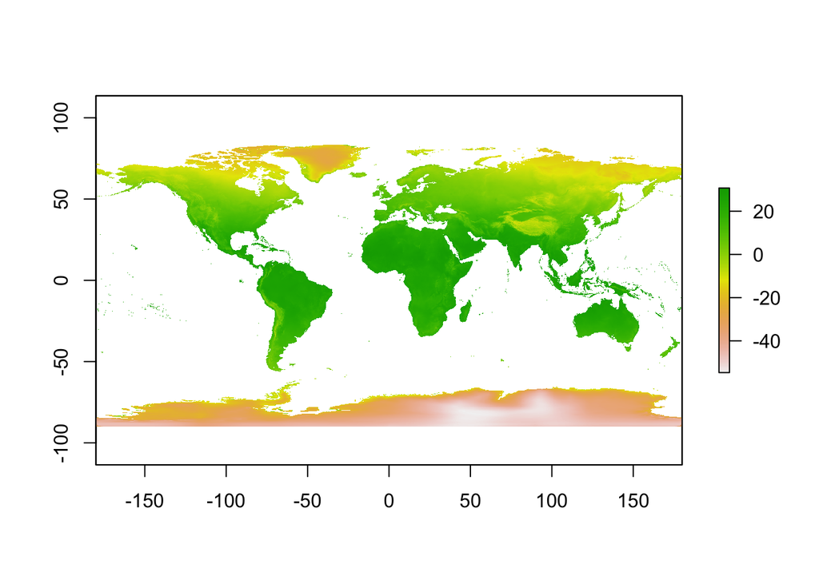

```r
plot(r)
```

```r
s <- stack(l)
s
```

```
## class      : RasterStack
## dimensions : 1080, 2160, 2332800, 19  (nrow, ncol, ncell, nlayers)
## resolution : 0.1666667, 0.1666667  (x, y)
## extent     : -180, 180, -90, 90  (xmin, xmax, ymin, ymax)
## crs        : +proj=longlat +datum=WGS84 +no_defs
## names      : wc2.1_10m_bio_1, wc2.1_10m_bio_10, wc2.1_10m_bio_11, wc2.1_10m_bio_12, wc2.1_10m_bio_13, wc2.1_10m_bio_14, wc2.1_10m_bio_15, wc2.1_10m_bio_16, wc2.1_10m_bio_17, wc2.1_10m_bio_18, wc2.1_10m_bio_19, wc2.1_10m_bio_2, wc2.1_10m_bio_3, wc2.1_10m_bio_4, wc2.1_10m_bio_5, ...
## min values :      -54.724354,       -37.781418,       -66.311249,         0.000000,         0.000000,         0.000000,         0.000000,         0.000000,         0.000000,         0.000000,         0.000000,        1.000000,        9.131122,        0.000000,      -29.686001, ...
## max values :        30.98764,         38.21617,         29.15299,      11191.00000,       2381.00000,        484.00000,        229.00169,       5284.00000,       1507.00000,       5282.00000,       4467.00000,        21.14754,       100.00000,      2363.84595,        48.08275, ...
```

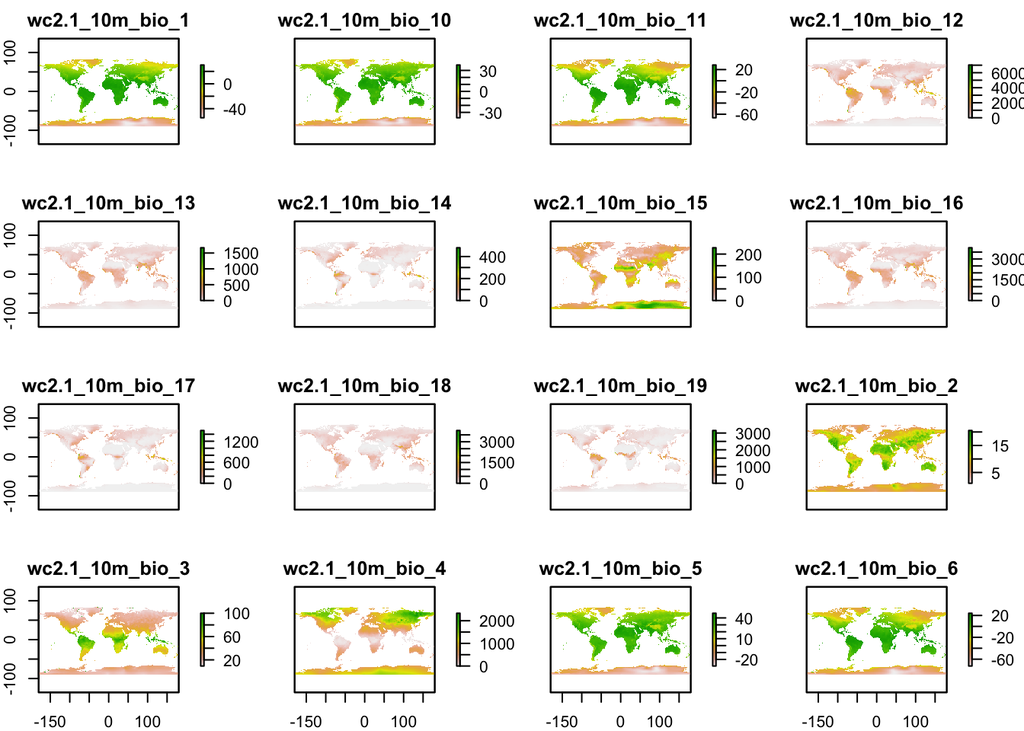

```r
plot(s)
```

A função `list.files` é particularmente útil pra detectar se determinados arquivos existem e trazer eles pra dentro do R. No argumento `pattern` nós declaramos qual o padrão que estamos querendo detectar. Podemos usar uma extensão, como o caso a cima, mas também podemos usar alguma particularidade do nome. Por exemplo, quando terminarmos de gerar nossos modelos teremos uma série de rasters com o nome da nossa espécie e o cenário projetado ou algo do gênero, assim: “Araucaria.angustifolia_current.tif”, “Araucaria.angustifolia_rcp26.tif”, “Araucaria.angustifolia_rcp45.tif”. Se eu quisesse trazer esses arquivos pra dentro do R usaria algo como: `list.files(pattern="Araucaria.angustifolia")`. Isso retornaria todos os arquivos (sendo eles rasters ou não) que possuam o nome que eu forneci dentro da minha pasta de trabalho. Mais dois argumentos são extremamente úteis nessa função. O argumento `rec` pode ser ativado com `rec=TRUE` ou desativado com `rec=FALSE`. Esse argumento, quando desativado, permite que a função busque arquivos apenas na pasta de trabalho. Quando ativamos ele, a função faz a busca dentro de sub-pastas, o que é particularmente útil quando temos muitas pastas dentro das pastas e é o cenário que vamos encontrar ao final dos nossos modelos, com diversos arquivos gerados. Não obstante, quando a função encontra um arquivo que possua o padrão desejado em uma sub-pasta, ela retorna apenas o nome do arquivo. Para importar ele pro R, nós precisamos saber todo o caminho que a função fez pra encontrar o arquivo. Assim, a gente ativa também um terceiro argumento chamado `full.names`.  
Salvando o resultado da função `list.files` em um objeto, podemos usar o objeto pra importar os arquivos detectados. No caso acima, detectamos diversos rasters e importamos o primeiro deles usando a função `raster`. Quando precisamos importar mais de um raster, podemos usar a função `stack` que é um objeto que guarda múltiplos rasters com a mesma extensão (latitude e longitude), mesmo datum e mesma resolução, apenas com nome e valores diferentes.

## Loops

Note que, ao criar um objeto stack, todos os rasters que indicamos foram importados no mesmo objeto. Às vezes, no entanto, queremos criar um objeto pra cada raster. Para isso, podemos utilizar um recurso chamado `loop`. Existem algumas maneiras de criar loops no R, a mais comum e a que vamos utilizar aqui é o `loop for`. Nós escrevemos um loop de forma semelhante a uma função, mas loops não são salvos em objetos. Um loop bem simples que podemos criar é o seguinte:

```r
for(x in 1:10){
  print(x)
}
```

```
## [1] 1
## [1] 2
## [1] 3
## [1] 4
## [1] 5
## [1] 6
## [1] 7
## [1] 8
## [1] 9
## [1] 10
```

O que estamos solicitando aqui é que o R repita a operação entre chaves substituindo o valor de x por, nesse caso, uma sequência de números. No contexto dos rasters, podemos fazer o seguinte loop:

```r
arquivos <- list.files(pattern = ".tif", rec=T, full.names=T)
arquivos
```

```
##  [1] "./wc2.1_10m_bio/wc2.1_10m_bio_1.tif"
##  [2] "./wc2.1_10m_bio/wc2.1_10m_bio_10.tif"
##  [3] "./wc2.1_10m_bio/wc2.1_10m_bio_11.tif"
##  [4] "./wc2.1_10m_bio/wc2.1_10m_bio_12.tif"
##  [5] "./wc2.1_10m_bio/wc2.1_10m_bio_13.tif"
##  [6] "./wc2.1_10m_bio/wc2.1_10m_bio_14.tif"
##  [7] "./wc2.1_10m_bio/wc2.1_10m_bio_15.tif"
##  [8] "./wc2.1_10m_bio/wc2.1_10m_bio_16.tif"
##  [9] "./wc2.1_10m_bio/wc2.1_10m_bio_17.tif"
## [10] "./wc2.1_10m_bio/wc2.1_10m_bio_18.tif"
## [11] "./wc2.1_10m_bio/wc2.1_10m_bio_19.tif"
## [12] "./wc2.1_10m_bio/wc2.1_10m_bio_2.tif"
## [13] "./wc2.1_10m_bio/wc2.1_10m_bio_3.tif"
## [14] "./wc2.1_10m_bio/wc2.1_10m_bio_4.tif"
## [15] "./wc2.1_10m_bio/wc2.1_10m_bio_5.tif"
## [16] "./wc2.1_10m_bio/wc2.1_10m_bio_6.tif"
## [17] "./wc2.1_10m_bio/wc2.1_10m_bio_7.tif"
## [18] "./wc2.1_10m_bio/wc2.1_10m_bio_8.tif"
## [19] "./wc2.1_10m_bio/wc2.1_10m_bio_9.tif"
```

```r
nomes <- list.files("wc2.1_10m_bio/",pattern = ".tif")
nomes
```

```
##  [1] "wc2.1_10m_bio_1.tif"  "wc2.1_10m_bio_10.tif" "wc2.1_10m_bio_11.tif"
##  [4] "wc2.1_10m_bio_12.tif" "wc2.1_10m_bio_13.tif" "wc2.1_10m_bio_14.tif"
##  [7] "wc2.1_10m_bio_15.tif" "wc2.1_10m_bio_16.tif" "wc2.1_10m_bio_17.tif"
## [10] "wc2.1_10m_bio_18.tif" "wc2.1_10m_bio_19.tif" "wc2.1_10m_bio_2.tif"
## [13] "wc2.1_10m_bio_3.tif"  "wc2.1_10m_bio_4.tif"  "wc2.1_10m_bio_5.tif"
## [16] "wc2.1_10m_bio_6.tif"  "wc2.1_10m_bio_7.tif"  "wc2.1_10m_bio_8.tif"
## [19] "wc2.1_10m_bio_9.tif"
```

```r
nomes <- gsub(".tif", "", nomes)
nomes <- gsub("wc2.1_10m_", "", nomes)
nomes
```

```
##  [1] "bio_1"  "bio_10" "bio_11" "bio_12" "bio_13" "bio_14" "bio_15" "bio_16"
##  [9] "bio_17" "bio_18" "bio_19" "bio_2"  "bio_3"  "bio_4"  "bio_5"  "bio_6"
## [17] "bio_7"  "bio_8"  "bio_9"
```

```r
for(i in 1:19){
  assign(nomes[i], raster(arquivos[i]))
}
```

Nós usamos aqui duas novas funções, `gsub` e `assign`. A primeira, busca por algum padrão e substitui ele. No caso, rodamos ela duas vezes, substituindo “.tif” e “wc2.1_10m_” por nada. Assim, ficamos só com o trecho que realmente importa. Perceba que a sequencia de nomes não vai do 1 para o 2, mas sim do 1 para o 10. Isso ocorre porque a sequencia detectada pela função list.files é em ordem alfabética. É importante manter a ordem dada, do contrário iremos atribuir nomes errados para os arquivos. Tendo criado esses dois elementos, podemos usar eles em um loop, aonde, a cada volta do loop, vamos criar um raster. Na primeira volta, iremos utilizar o primeiro elemento do objeto `nomes` como nome do primeiro elemento do objeto `arquivos`. A função `assign` vai fazer essa atribuição de nomes pra nós. Essa função é particularmente útil para que a gente consiga dar nomes diferentes para os diferentes objetos que serão criados.  
Lembre-se que você sempre pode buscar pelo arquivo de ajuda da função utilizando `?NOME_DA_FUNÇÃO`.

## Shapefiles

Shapesfiles são pontos ou linhas que conseguimos traçar em um mapa. Fronteiras de um país ou pontos de presença de uma espécie são exemplos bem próximos de shapes. Nós podemos usar a função `shapefile` do pacote `raster` pra importar shapes. Caso você não esteja usando um computador com Windows, pode recorrer à função `readOGR` do pacote `rgdal`. Vamos começar baixando um shapefile. [Aqui](http://www.fepam.rs.gov.br/biblioteca/geo/limite_RS.zip) é possível baixar os limites do estado do Rio Grande do Sul. Coloque o arquivo deszipado na pasta de trabalho e vamos importar o shape para dentro do R:

```r
library(rgdal)
rs <- readOGR("limite_RS/Limite_RS.shp")
rs
```

```
## class       : SpatialPolygonsDataFrame
## features    : 1
## extent      : -57.64773, -49.69763, -33.75132, -27.07825  (xmin, xmax, ymin, ymax)
## crs         : +proj=longlat +ellps=GRS80 +towgs84=0,0,0,0,0,0,0 +no_defs
## variables   : 5
## names       :    AREA, PERIMETER, RSLIMITELL, RSLIMITE_1,            HA
## value       : 26.2933,   32.8734,          2,          0, 28200921.4714
```

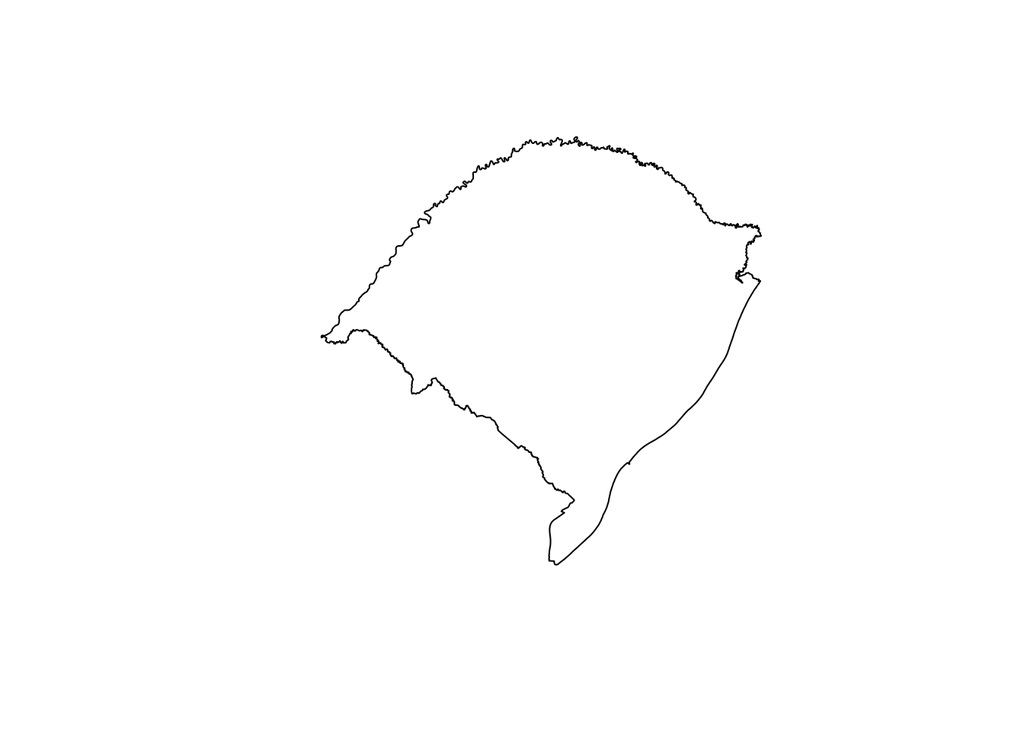

```r
plot(rs)
```

## Conclusões

Nesse momento, vimos como importar dados ambientais na forma de shapes ou rasters para o R. Também aprendemos um novo recurso, o loop, que otimiza tarefas repetitivas.

### Exercício:

1. Uma das tarefas que teremos que desenpenhar, antes de gerar modelos, é recortar dados ambientais para se adequarem à nossa área de trabalho. Tente recortar o raster e o stack utilizando o shape que construímos na aula. Algumas funções que podem ser úteis são a função `crop` e a função `mask`.